# Logboek_Jasper

Jasper

2024-05-13

# inleiding

Dit is het logboek van de volgende onder zoeksvraag:

*Is er een verschil tussen de ethische meningen van mensen van andere leeftijden, geslachten en geloof?*  
Dit gaan we doen met behulp van een enquête en een verwerking in R studio.  
De enquête wordt verspreid over meerdere mensen van verschillende leeftijdsgroepen. Hierdoor hopen we meerdere leeftijdsgroepen te kunnen interviewen.  
De vragen waar we voor hebben gekozen zijn ja en nee vragen zonder toelichting van de invuller in te zetten. Want dat is moeilijker te verwerken dan bijvoorbeeld ” wat is uw gevoel hier bij?“. Dan krijg je meer niet echt duidelijke data.  
We hebben wel op het eind een paar stellingen met waardes als zeer oneens tot zeer eens.  
We hebben er voor gekozen om in Microsoft Forms te doen omdat je dan ook een csv file van kan maken.

# Logboek

## 22 april tot 26 april

In deze periode hebben we vooral gekeken naar wat we wouden onderzoeken en wat.  
We hebben uiteindelijk gekozen voor abortus.  
Omdat dit een etnische kwestie is, maar niet zo zwaar ligt als bijvoorbeeld vluchtelingen. Hierdoor hopen we dat de drempel voor sommige mensen om het in te vullen weg te nemen.  
Ook is het al vaak in het nieuws geweest. Hierdoor hopen we te voorkomen dat mensen dit onderwerp zien en geen mening er over hebben en daardoor het niet meer gaan invullen

## 27 april tot 6 mei

In deze periode hebben we de informatie gezocht over het onderwerp en maakte we ook een enquête die we hebben laten zien aan andere personen.  
Het laatste deden we door onafhankelijke persoon zodat we fouten er uit konden krijgen. Fouten zoals een te sturende vraag of een onduidelijke vraag.  
En wat we achterkwamen was bijvoorbeeld over de bedenk tijd die veranderd is. Dus wel interessante om te kijken wat de menig er over is.

## 7 mei

Begonnen we met de enquête na alle goedkeuringen. Deze goedkeuring kwam van onze docent.  
De enquête hebben we verspreid over eerst onze klas en daarna over ouders en die vrienden er van. Ook ozne eigen vrienden zin gevraagd.

## 8 mei

Meerdere mensen gevraagd om het in te vullen.

## 9 mei tot 3 juni

enquête open laten staan en allemaal meet waarden binnen krijgen en bedenken waar het nog meer hebben kunnen uit delen. Ik denk er over na om bij mij op werk te verspreiden. Dit omdat het meer mensen waar je misschien normaal niet mee om gaat en daardoor een andere mening hebben dan ons. Zodat we betere meetwaarde kunnen hebben.

## 14 mei

```
## ✖ lubridate::%--%()      masks igraph::%--%()
```

We gaan al bezig met het uitwerken van de meetwaarde op dit moment. zodat we later alleen de data hoeven te updaten. En zo kunnen we alvast bezig en blijven we niet stil zitten.  
Hier worden wat namen veranderd want anders krijg je namen als *Vindt.u.dat.iemand.zelf.moet.kunnen.kiezen.of.die.een.abortus.wil* en dat is veel te lang. We willen het nog wel kunnen lezen blijven en is het handig altijd goeie naamgeving

```r
abortus <- read.csv("abortus_dataset.csv",
                    na.strings = "NA")
#table(abortus$Vindt.u.dat.iemand.zelf.moet.kunnen.kiezen.of.die.een.abortus.wil., useNA = "always")



# voor de vraag: Vindt u dat iemand zelf moet kunnen kiezen of die een abortus wil?
abortus$eigen_keuze_abortus <- factor(x = abortus$Vindt.u.dat.iemand.zelf.moet.kunnen.kiezen.of.die.een.abortus.wil.,
                           levels = c("Ja", "Nee"),
                           labels = c("Wel abortus toestaan", "Geen abortus toestaan"))

# Voor de vraag: Wat is uw religieuze overtuiging?
abortus$geloof <- factor(x = abortus$Wat.is.uw.religieuze.overtuiging..,
                           levels = c("Christendom", "Islam", "Hindoeïsme", "Boeddhisme", "Niet gelovig", "Anders"),
                           labels = c("Christendom", "Islam", "Hindoeïsme", "Boeddhisme", "Niet gelovig", "Anders"))


abortus$geslacht <- factor(x = abortus$Wat.is.uw.geslacht..,

                           levels = c("Man", "Vrouw", "Wil ik liever niet melden"),
                           labels = c("Man", "Vrouw", "Wil ik liever niet melden"))


# Voor de vraag: Wat is uw religieuze overtuiging?

abortus$afkomst <- factor(x = abortus$In.welke.provincie.heeft.u.het.grootste.deel.van.uw.jeugd.doorgebracht.,
                           levels = c("Drenthe", "Flevoland", "Friesland", "Gelderland", "Groningen", "Limburg", "Noord-Brabant", "Noord-Holland", "Overijssel", "Utrecht", "Zeeland", "Zuid-Holland", "Ik ben niet in Nederland opgegroeid"),
                           labels = c("Drenthe", "Flevoland", "Friesland", "Gelderland", "Groningen", "Limburg", "Noord-Brabant", "Noord-Holland", "Overijssel", "Utrecht", "Zeeland", "Zuid-Holland", "Buitenland"))


abortus <- abortus %>%
    rename(
        leeftijd = Wat.is.uw.leeftijd. ,
        ouderszegenschap = Vindt.u.dat.de.ouders.zeggenschap.moeten.hebben.over.of.hun.minderjarige.kind.wel.of.niet.voor.abortus.mag.kiezen... ,
        Kindskeuze = Vindt.u.dat.een.minderjarig.kind.de.keuze.moet.hebben.om.voor.een.abortus.te.kiezen.....
    )
```

Ik ga even kijken de gemiddelde leeftijd kijken van onze ingevulde mensen. En kijken naar de verdeling van dit. Wat Q1 is of Q2 is als voorbeeld.

```r
summary(abortus$leeftijd)
```

```
##    Min. 1st Qu.  Median    Mean 3rd Qu.    Max.
##   15.00   21.25   45.00   40.87   54.00   80.00
```

Hier ga ik een grafiek maken om te kijken of de leeftijd normaal verdeeld is.

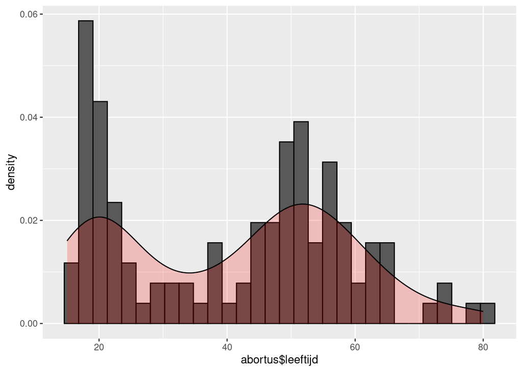

```r
leeftijd <- data.frame(abortus$leeftijd)

ggplot(leeftijd, aes(x=abortus$leeftijd)) + geom_histogram(aes(y =after_stat(density)), color = "black")+geom_density(alpha = .2, fill= "red")
```

Hier zie dat het niet helemaal normaal verdeelt is, dit komt omdat het eerst is verspreid onder de mede studenten en aan hun ouders. Hierdoor krijg je in sommige gebieden meer invullingen. In de grafriek zie je ook dat het ook terug komen.

Hier zie dat het niet helemaal normaal verdeelt is maar kunnen wel een test doen

```r
shapiro.test(abortus$leeftijd)
```

```
##
##  Shapiro-Wilk normality test
##
## data:  abortus$leeftijd
## W = 0.9217, p-value = 5.044e-06
```

Hier zie zeker dat de leeftijd van onze invuller niet normaal verdeelt is.

## 15 mei.

Ik laat zien waar onze invuller vandaan komen in een donut chart.

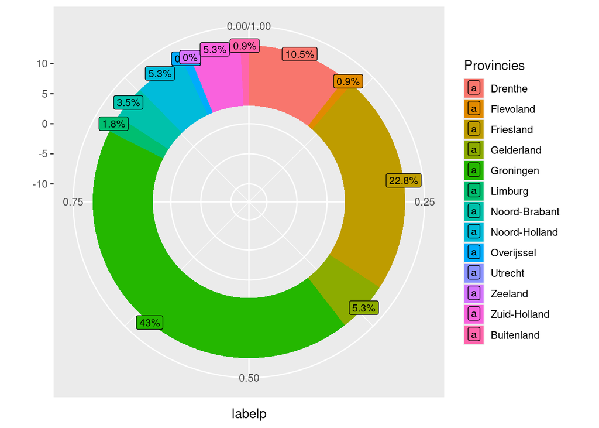

```r
x <- table(abortus$afkomst)
city_count <- data.frame(x)
# percentages berekenen
city_count$fraction = city_count$Freq / sum(city_count$Freq)
city_count$percentage = round(city_count$fraction *100, digits =1)
city_count$ymax = cumsum(city_count$fraction)
city_count$ymin = c(0, head(city_count$ymax, n=-1))
city_count$labelp = (city_count$ymax+city_count$ymin)/2
city_count$label = (paste0(city_count$percentage, "%"))
renamed_city_count <- city_count %>%
    rename(
        Provincies = Var1
    )

# Make the plot
ggplot(renamed_city_count, aes(ymax=ymax, ymin=ymin, xmax=13, xmin=3, fill=Provincies)) +
     geom_rect() +
     geom_label( x = 13, aes(y=labelp, label= label), size=3)+

     coord_polar(theta="y") +
     xlim(c(-13, 13))
```

Hier kan je zien dat de meeste mensen uit de noordelijke regio komen. Dus uit Drenthe, Friesland en Groningen Dit is logisch omdat we de enqute hebben uit gezet in de noordelijke provincies.  
Ook een boxplot gemaakt over de verdeling van de leeftijd als oefening

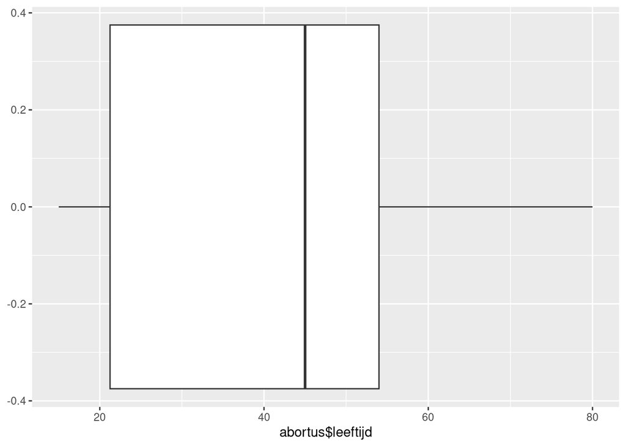

```r
ggplot(leeftijd, aes(x = abortus$leeftijd)) + geom_boxplot()
```

## 16 mei

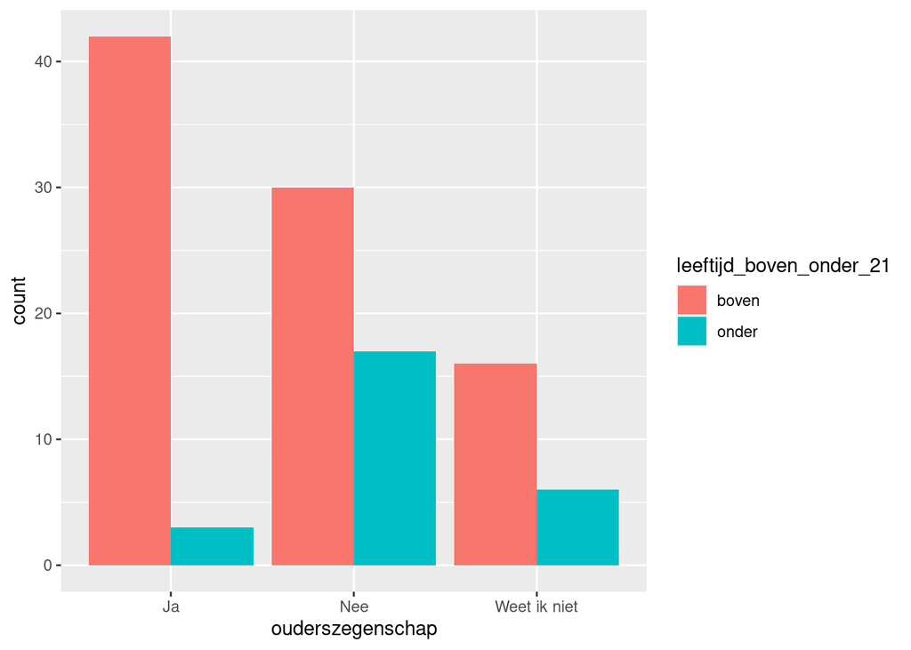

```r
abortus %>%
    select(leeftijd, ouderszegenschap) %>%
    mutate(leeftijd_boven_onder_21 = ifelse(leeftijd > 21, "boven", "onder")) %>%

    mutate(leeftijd_boven_onder_21 = ifelse(leeftijd >= 21, "boven", "onder")) %>%

    ggplot(mapping = aes(x = ouderszegenschap, fill = leeftijd_boven_onder_21)) +
    geom_bar(position = "dodge")
```

Dit is geen goeie plot om te laten zien wat de verschillen zijn in antwoorden. Hier laat je nu het aantal keer zien dat het is ingevuld. Hierdoor lijkt het dat ja heel vaak word in gevuld terwijl het gewoon minder vaak is ingevuld door iemand onder de leeftijd van 21 jaar  
Ik ga nog bedenken wat een goeie manier is om het te laten zijn en een goede vergelijking te kunnen maken.

## 21 Mei

Ik ga even met iets anders bezig het lukt niet echt.  
De keuze dat we hebben gemaakt voor de leeftijd van 21 jaar want over de helle wereld is 21 jaar de oudste leeftijd van de wereld. We hadden ook kunnen kiezen voor 18 jaar. Want in Nederland is dat de grens. Maar als je kijkt naar Amerika is er een onderzoek geweest naar de connectie met de legale leeftijd van drinken en auto ongelukken. Hier is naar voren gekomen dat hoe lager de leeftijd hoe meer auto ongelukken er zijn. Hier kan je bijvoorbeeld uit concluderen dat deze mensen nog niet verantwoordelijk genoeg zijn om met alcohol om te gaan, https://www.ncbi.nlm.nih.gov/pmc/articles/PMC6876521/

## 22 mei

Ik ga de tabel van 16 mei om zetten naar percentage. zo dat het wel klopt en niet op aantallen gaat. en we zijn verwisseld van de leeftijd van 21 naar 25 jaar. Dit doen we omdat we hebben gedaan omdat je brein eigenlijk niet 100% volgroeid zijn op de leeftijd van 21. Dit gebeurt wel rond die periode. van 20 tot 25 jaar. Daarom kiezen we voor de leeftijd van de 25 jaar omdat dan volgense de wetenschap je brein helemaal vol groeit zijn en denken wij ook dat je de juitse keuzes kan maken.

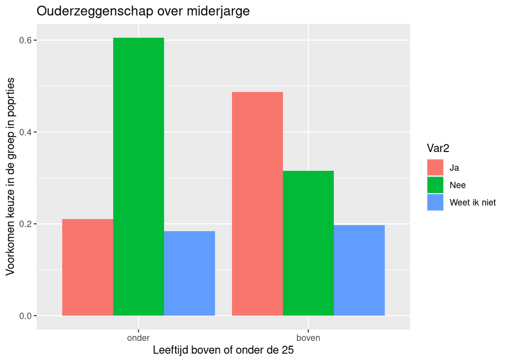

```r
#hier maak ik een splitsing van de leeftijden boven en onder
Spiltsing_leeftijd <-abortus %>%
    select(leeftijd, ouderszegenschap, geslacht) %>%
    mutate(leeftijd_boven_onder_24 = ifelse(leeftijd > 25, "boven", "onder"))
#Hier maak ik een tabel van de leeftijd boven de 25
table_Boven_25 <- prop.table(table(Spiltsing_leeftijd$leeftijd_boven_onder_24[Spiltsing_leeftijd$leeftijd_boven_onder_24 == "boven"], Spiltsing_leeftijd$ouderszegenschap[Spiltsing_leeftijd$leeftijd_boven_onder_24 == "boven"]))
#Hier maak ik een tabel voor de leeftijd tot en met de leeftijd van 25
table_Onder_25<- prop.table(table(Spiltsing_leeftijd$leeftijd_boven_onder_24[Spiltsing_leeftijd$leeftijd_boven_onder_24 == "onder"], Spiltsing_leeftijd$ouderszegenschap[Spiltsing_leeftijd$leeftijd_boven_onder_24 == "onder"]))
#hier worden de twee tabellen samengevoegd
table_onder_boven_samen <- rbind(table_Onder_25,table_Boven_25)
#hier wordt de grafiek gemaakt van de twee de laaste tabel
as.data.frame.table(table_onder_boven_samen) %>%
    ggplot(aes(x = Var1,y = Freq,  fill = Var2)) +
    geom_col(position = "dodge")+
    guides(color = guide_legend(title = "Wat is de mening")) +
    labs(title = "Ouderzeggenschap over miderjarge",
         y = "Voorkomen keuze in de groep in poprties",
         x = "Leeftijd boven of onder de 25")
```

Hier zie je dus dat de mening erg verschild over zeggenschap van de ouders.  
Jongeren hebben willen nee en ouderen zeggen ja, dit is ook wel logisch want pubers luisteren ook niet echt naar hun ouders en ouders weten het altijd beter zeggen ze zelf, dus is de verdeling eigenlijk best we logisch.

## 23 mei

De grafiek van boven mooi maken en testen gaan uit voeren op de de laatste grafiek. De grafiek is goed gelukt nu dus dat is klaar.

## 27 mei

Ik ga een chi square test doen. Of het geslacht mee telt voor mensen onder de leeftijd van 25 over het onderwerp mening van ouders  
De leeftijd van 25 is gekomen omdat de hersenen tussen de leeftijd van 20 en 25 jaar volgroeid is. Daarom is de vorige figuur ook verander naar de leeftijd van 25 jaar.  
>H0 de leeftijd heeft geen significat verschil op de mennig over zeggenenschap van de ouders bij de leeftijd groep van onder 25

```r
# 1 voor de mensen de voorstander zijn, 0 als
#ze tegen zijn.

# Chi-square test:
#chi tesit over de leeftidijd onder de 25 over zeggen schap van de ouders
chi_abortus_minderjarig_keuze_onder <- chisq.test(table_Onder_25,  correct = T)
chi_abortus_minderjarig_keuze_onder
```

```
##
##  Chi-squared test for given probabilities
##
## data:  table_Onder_25
## X-squared = 0.3338, df = 2, p-value = 0.8463
```

```r
#chi tesit over de leeftidijd boven de 25 over zeggen schap van de ouders
chi_abortus_minderjarig_keuze_boven <- chisq.test(table_Boven_25, correct = T)
chi_abortus_minderjarig_keuze_boven
```

```
##
##  Chi-squared test for given probabilities
##
## data:  table_Boven_25
## X-squared = 0.12708, df = 2, p-value = 0.9384
```

## 28 mei

Met de paper bezig geweest de introductie geschreven en met de powerpoint bezig geweest

## 29 mei

De vorige Chi square test is fout gegaan, ik heb gekeken of onder de leeftijd van 25 een significant verschil zit en boven de leeftijd van 25 en dat was er beide niet, en ik kijk ook niet echt dan tussen de geslachten maar alleen naar de leeftijden en wat ze hebben ingevuld.  
Hieronder is de juiste chi square testen

```r
#heen chi test tussen de verschillende twee groepen.
abortus_aangpast <- abortus %>%
    mutate(leeftijd_boven_onder_24 = ifelse(leeftijd > 25, "boven", "onder"))
Boven_onder_Ouderzegschap <-table(abortus_aangpast$leeftijd_boven_onder_24, abortus_aangpast$ouderszegenschap)
(chi_leeftijd_Ouderzegschap <-chisq.test(Boven_onder_Ouderzegschap, correct = T))
```

```
##
##  Pearson's Chi-squared test
##
## data:  Boven_onder_Ouderzegschap
## X-squared = 10.072, df = 2, p-value = 0.006501
```

Hier uit is te zien dat er wel een significant verschil is tussen de verschillende leeftijd groepen.  
Hier onder hebben we de de manier van de chis square test veranderd.

```r
#oefening
tabel_ofen <- table(abortus$geslacht, abortus$eigen_keuze_abortus)

chisq.test(tabel_ofen)
```

```
##
##  Pearson's Chi-squared test
##
## data:  tabel_ofen
## X-squared = 3.4768, df = 2, p-value = 0.1758
```

Er wordt nu telkens een chisp.test te doen op elke vraag.

```r
Boven_onder_kidskeuze <-table(abortus_aangpast$leeftijd_boven_onder_24, abortus_aangpast$Kindskeuze)
(chi_leeftijd_kids_eigen_keuze<-chisq.test(Boven_onder_kidskeuze, correct = T))
```

```
##
##  Pearson's Chi-squared test
##
## data:  Boven_onder_kidskeuze
## X-squared = 4.0816, df = 2, p-value = 0.1299
```

```r
Boven_onder_Wel_geen <-table(abortus_aangpast$leeftijd_boven_onder_24, abortus_aangpast$Vindt.u.dat.iemand.zelf.moet.kunnen.kiezen.of.die.een.abortus.wil.)
 (chi_leeftijd_eigen_keuze_alegemeen <-chisq.test(Boven_onder_Wel_geen, correct = T))
```

```
##
##  Pearson's Chi-squared test with Yates' continuity correction
##
## data:  Boven_onder_Wel_geen
## X-squared = 0.80966, df = 1, p-value = 0.3682
```

```r
Boven_onder_Vader<-table(abortus_aangpast$leeftijd_boven_onder_24, abortus_aangpast$Moet.de.biologische.vader.zeggenschap.hebben.over.de.beslissing.voor.een.abortus.)
(chi_leeftijd_vaderszeggenschap <-chisq.test(Boven_onder_Vader, correct = T))
```

```
##
##  Pearson's Chi-squared test
##
## data:  Boven_onder_Vader
## X-squared = 1.0286, df = 2, p-value = 0.5979
```

## 30 mei

Ik a bezig met meer Chi squar testen zo dat ik ze zo meteen in een grafriek kan stoppen om in 1 keer te kunnenlaten zien waar een sinficant verschil is

```r
Boven_onder_Keuze_Gevaar_moeder <-table(abortus_aangpast$leeftijd_boven_onder_24, abortus_aangpast$Vindt.u.dat.er.voor.abortus.gekozen.mag.worden.als.de.gezondheid.van.de.vrouw.door.de.zwangerschap.in.gevaar.kan.komen.)
(chi_leeftijd_keuze_Gevaar_moeder <-chisq.test(Boven_onder_Keuze_Gevaar_moeder, correct = T))
```

```
##
##  Pearson's Chi-squared test with Yates' continuity correction
##
## data:  Boven_onder_Keuze_Gevaar_moeder
## X-squared = 0.063616, df = 1, p-value = 0.8009
```

```r
Boven_onder_Keuze_verkachting <-table(abortus_aangpast$leeftijd_boven_onder_24, abortus_aangpast$Vindt.u.dat.iemand.een.abortus.mag.als.de.zwangerschap.een.gevolg.is.van.verkrachting.)
(chi_leeftijd_keuze_verkrachting <-chisq.test(Boven_onder_Keuze_verkachting, correct = T))
```

```
##
##  Pearson's Chi-squared test with Yates' continuity correction
##
## data:  Boven_onder_Keuze_verkachting
## X-squared = 1.0232e-28, df = 1, p-value = 1
```

```r
Boven_onder_Keuze_zonder_reden <-table(abortus_aangpast$leeftijd_boven_onder_24, abortus_aangpast$De.vrouw.het.kind.niet.wil.houden.om.niet.gespecificeerde.redenen)
(chi_leeftijd_keuze_zonder_reden <-chisq.test(Boven_onder_Keuze_zonder_reden, correct = T))
```

```
##
##  Pearson's Chi-squared test
##
## data:  Boven_onder_Keuze_zonder_reden
## X-squared = 13.469, df = 7, p-value = 0.06148
```

```r
Boven_onder_Keuze_Echo <-table(abortus_aangpast$leeftijd_boven_onder_24, abortus_aangpast$Moet.het.wettelijk.verplicht.worden.voor.vrouwen.die.een.abortus.willen.om.een.echo.van.de.foetus.te.zien.voordat.een.abortus.toegestaan.is.)
(chi_leeftijd_keuze_echo <-chisq.test(Boven_onder_Keuze_Echo, correct = T))
```

```
##
##  Pearson's Chi-squared test
##
## data:  Boven_onder_Keuze_Echo
## X-squared = 1.25, df = 2, p-value = 0.5353
```

```r
Boven_onder_Keuze_bedenktijd <-table(abortus_aangpast$leeftijd_boven_onder_24, abortus_aangpast$Vindt.u.dat.de.wettelijke.bedenktijd.moet.terugkomen.)
(chi_leeftijd_keuze_bedenktijd <-chisq.test(Boven_onder_Keuze_bedenktijd, correct = T))
```

```
##
##  Pearson's Chi-squared test
##
## data:  Boven_onder_Keuze_bedenktijd
## X-squared = 4.3077, df = 2, p-value = 0.116
```

```r
Boven_onder_Keuze_adoptie <-table(abortus_aangpast$leeftijd_boven_onder_24, abortus_aangpast$Vindt.u.dat.adoptie.een.alternatief.is.voor.abortus.)
(chi_leeftijd_keuze_adoptie <-chisq.test(Boven_onder_Keuze_adoptie, correct = T))
```

```
##
##  Pearson's Chi-squared test
##
## data:  Boven_onder_Keuze_adoptie
## X-squared = 4.75, df = 2, p-value = 0.09301
```

```r
Boven_onder_Keuze_vader <-table(abortus_aangpast$leeftijd_boven_onder_24, abortus_aangpast$Moet.de.biologische.vader.zeggenschap.hebben.over.de.beslissing.voor.een.abortus.)
chi_leeftijd_keuze_vader <-chisq.test(Boven_onder_Keuze_vader, correct = T)
chi_leeftijd_keuze_vader
```

```
##
##  Pearson's Chi-squared test
##
## data:  Boven_onder_Keuze_vader
## X-squared = 1.0286, df = 2, p-value = 0.5979
```

Hier onder word de plot gemaakt

```r
# hier worden alle waardes van de chi testen bij elkaar geveogd
chi_test_vector_leeftijd <- c(chi_leeftijd_eigen_keuze_alegemeen[3], chi_leeftijd_keuze_verkrachting[3], chi_leeftijd_kids_eigen_keuze[3],chi_leeftijd_Ouderzegschap[3], chi_leeftijd_keuze_echo[3],chi_leeftijd_keuze_bedenktijd[3],chi_leeftijd_keuze_adoptie[3],chi_leeftijd_vaderszeggenschap[3])
# Hier worden ze weer hernoemd.
df_chi_leeftijd <- (data.frame((chi_test_vector_leeftijd)) %>% rename(
  `Abortus toestaan` = p.value,
  `Gevolg van verkrachtign` = p.value.1,
  `Minderjarig kind` = p.value.2,
  `Zeggenschap ouders` = p.value.3,
  `Echo bekijken` = p.value.4,
  `Bedenktijd invoeren` = p.value.5,
  `Adoptie als alternatief` = p.value.6,
  `Zeggenschap vader` = p.value.7
  ))
```

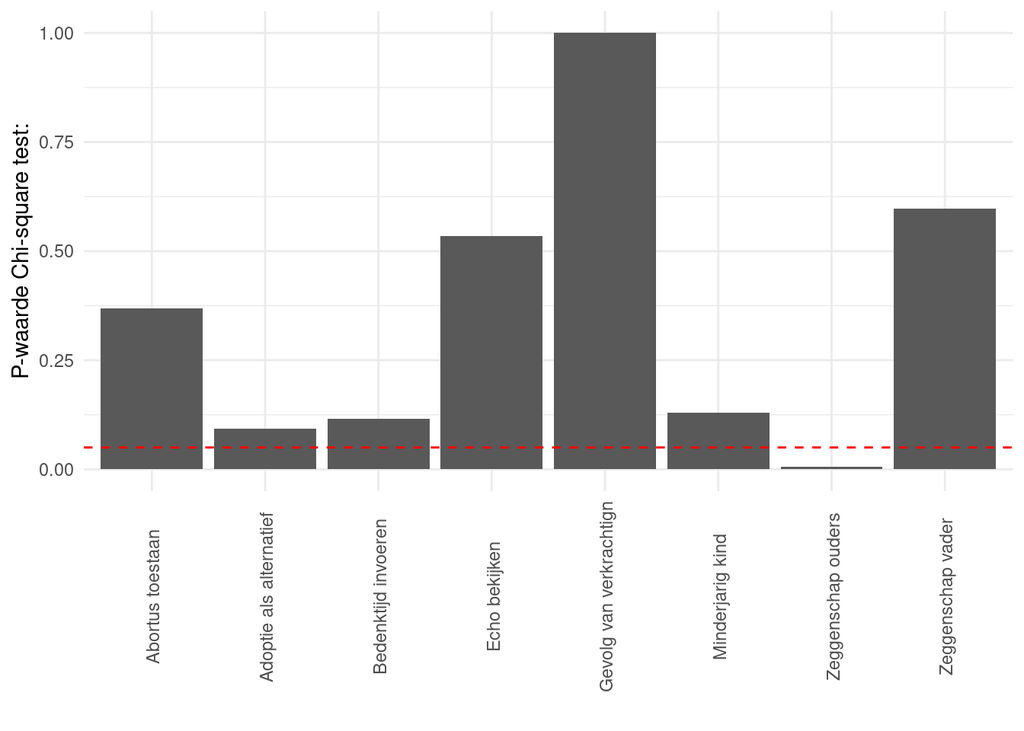

```r
# hier wordt er een gafriek van gemaakt

df_chi_leeftijd %>%
  pivot_longer(cols = c(1:8)) -> df_chi_leeftijd
ggplot(data = df_chi_leeftijd, mapping = aes(x = name , y = value)) +
  geom_bar(stat = "identity") +
  geom_hline(yintercept=0.05, linetype="dashed", color = "red") +
  ylab("P-waarde Chi-square test:") +
  xlab(" ") +
  theme_minimal() +
  theme(axis.text.x = element_text(angle = 90, vjust = 0.6))
```

## 2 Juni

Bezig gegaan met de paper met de introductie zodat het gedaan is en zorgt voor een betere taalgebruik tijdens het schrijven.

## 3 juni

De introductie was al geschreven door 1 van de team genoten terwijl het mijn werk was.  
Ben vervolgens bezig geweest om alle grafieken om gezet in de paper naar percentage in plaats van aantallen.  
Ik ga ook mijn laatste grafiek toevoegen aan de paper om nog beter te vergelijken met verschil waar je naar kijkt.

## 4juni

Puntjes op de i. Dus de referenties toegevoegd en het protocol bij gewerkt.